# Understanding Factors That Influence Insurance Charges

Sean Schilk

9/14/2025

# 1 Introduction

In this assignment, we are fitting a simple linear regression (SLR) by selecting a numerical explanatory variable from the data set using the least square approach and then constructing 95% bootstrap confidence intervals for the regression coefficients.

# 2 Data Set and Practical Questions

I’m using a data set provided by Mosap Abdel-Ghany on Kaggle called “Medical Insurance Cost Dataset”. The data was collected from a collection of 1338 individuals from medical insurance records.

The primary practical question is to see how the variables in the data set or derived variables from the data set affect insurance cost.

# 3 Data Description

The variables names in the data set and their variable type are the following:

age (numeric) sex (character) bmi (numeric) - a measure of body fat based on height and weigh children (numeric) - Number of children covered by health insurance smoker (character) - Smoking status of the beneficiary region (character)- Residential region in the US charges (numeric) - Medical insurance cost billed to the beneficiary

# 4 Exploratory Data Analysis

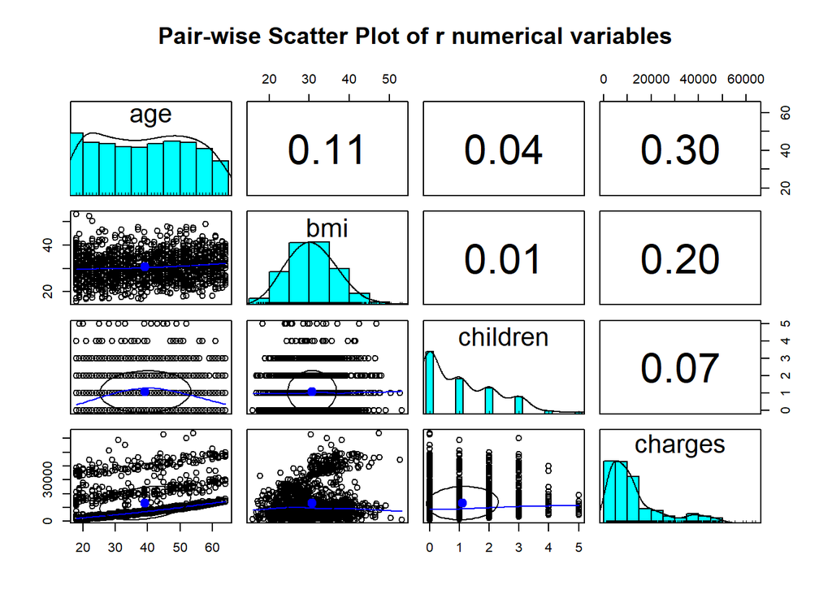

```r
# Read in dataset
library(readr)
library(psych)
insurance <- read_csv("https://sschilk.github.io/Topics-In-Advanced-Statistics/datasets/insurance.csv")

#Remove rows with categorical variables
pairs.panels(insurance[, -c(2,5,6)], pch=21,
             main="Pair-wise Scatter Plot of r numerical variables") #to show color grouping
```

We choose age as the explanatory variable in the analysis, as it had the highest correlation to our response, charges, the medical insurance cost billed to the beneficiary.

Let’s make a scatter plot between our explanatory and response variables

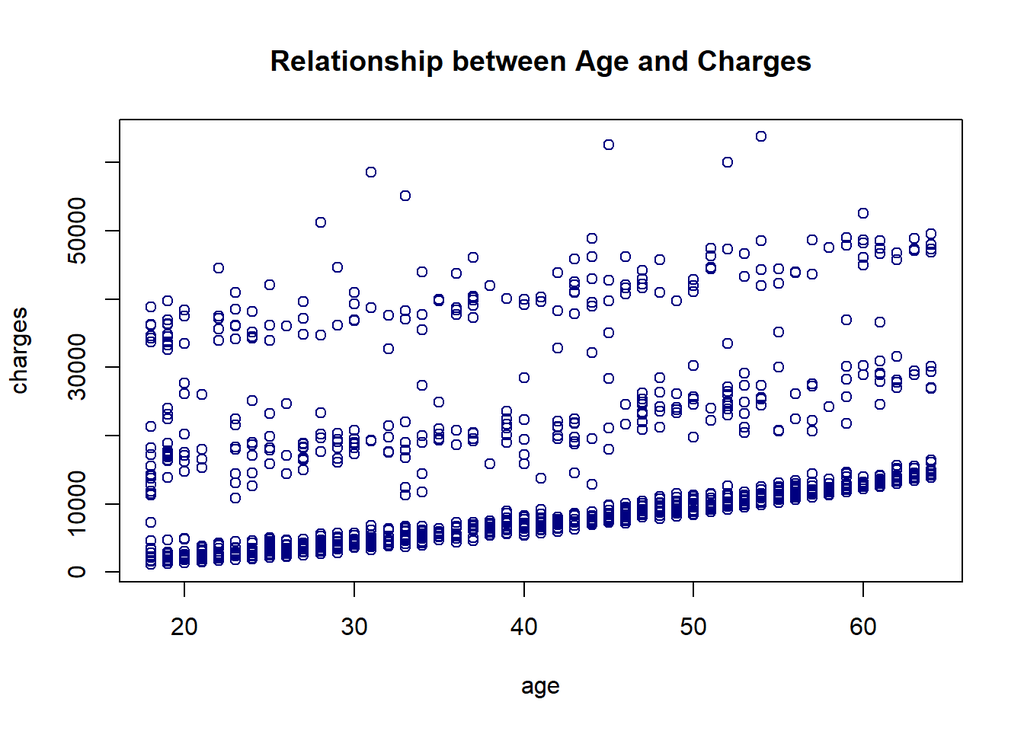

```r
age <- insurance$age
charges <- insurance$charges
plot(age, charges, pch = 21, col = "navy", main = "Relationship between Age and Charges")
```

The above scatter plot indicates a positive linear association between the charges billed to the beneficiary and age of individual. I’m guessing the patterns could be explained by levels of insurance. If you have little to no insurace, at any age, you’ll pay more. This is something we’d have to adjust for in a later project.

Now let’s look at our assumptions.

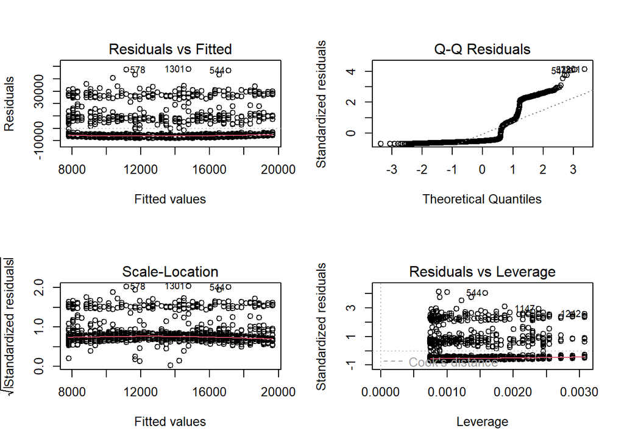

```r
parametric.model <- lm(charges ~ age)
par(mfrow = c(2,2)) # include all plots
plot(parametric.model)
```

Starting top left, our residuals vs fitted plot is not randomly scattered around y=0, so our assumption of constant variance is violated. The QQ plot shows our assumption of normality is also violated. We can also see the presence of some outliers in the bottom right graph.

We will use a box-cox transformation here on the response.

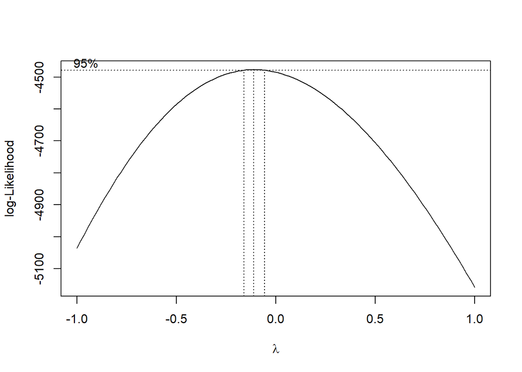

```r
library(MASS)
boxcox(lm(charges ~ age), lambda = seq(-1, 1, 1/10))
```

lambda looks to be about -.1. So we have the following graphs:

```r
lambda=-.1
charges.tenth = (charges^lambda - 1)/lambda
boxcox.m = lm(charges.tenth ~ age)
```

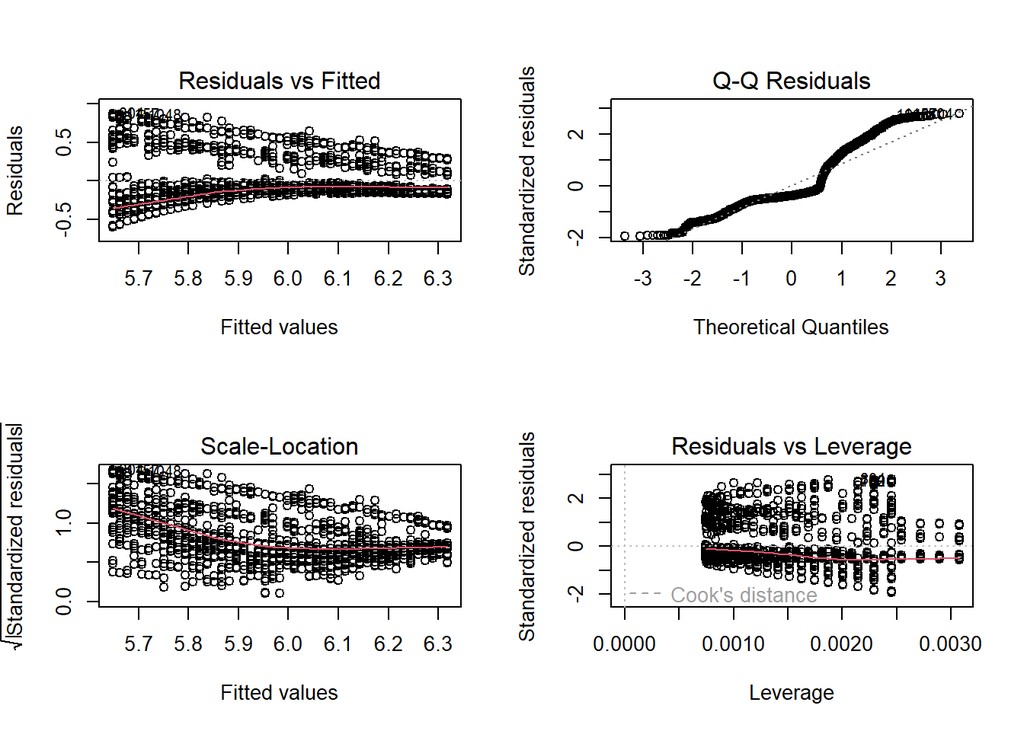

```r
par(mfrow=c(2,2))
plot(boxcox.m)
```

We can see the transformation significantly improved our plots, but the violations of our assumptions are still present. Therefore we will use bootstrap procedure to fit the linear regression model. The inferential statistics based on the above model are summarized in the following table.

```r
library(pander)
reg.table <- coef(summary(parametric.model))
pander(reg.table, caption = "Inferential statistics for the parametric linear
      regression model: charges to beneficiary and age of individual")
```

Inferential statistics for the parametric linear regression model: charges to beneficiary and age of individual

|  | Estimate | Std. Error | t value | Pr(>\|t\|) |
| --- | --- | --- | --- | --- |
| **(Intercept)** | 3166 | 937.1 | 3.378 | 0.0007506 |
| **age** | 257.7 | 22.5 | 11.45 | 4.887e-29 |

We will not discuss the p-value since the residual plots indicate potential violations of the model assumption. In other words, the p-value may be wrong. A descriptive interpretation of the slope parameter is that, as the age of an individual increases by 1 year, the corresponding charge to beneficiary increases by $257.7.

Since the sample size is 1338. The bootstrap regression method will produce a robust confidence interval of the slope of the distance. If 0 is not in the confidence interval, then the slope is significant. The following steps construct bootstrap confidence intervals of regression coefficients.

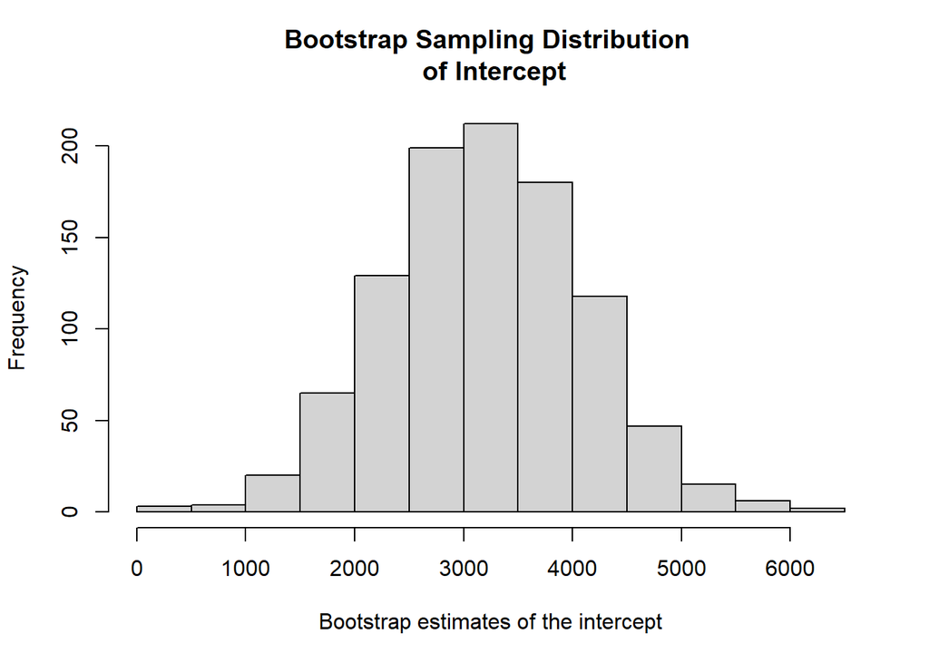

```r
B <- 1000    # number of bootstrap replicates
# define empty vectors to store bootstrap regression coefficients
boot.beta0 <- NULL
boot.beta1 <- NULL
## bootstrap regression models using for-loop
vec.id <- 1:length(charges)   # vector of observation ID
for(i in 1:B){
  boot.id <- sample(vec.id, length(charges), replace = TRUE)   # bootstrap obs ID.
  boot.charges <- charges[boot.id]           # bootstrap charges
  boot.age <- age[boot.id]     # corresponding bootstrap age
  ## regression
  boot.reg <-lm(charges[boot.id] ~ age[boot.id])
  boot.beta0[i] <- coef(boot.reg)[1]   # bootstrap intercept
  boot.beta1[i] <- coef(boot.reg)[2]   # bootstrap slope
}

#PLOT
hist(boot.beta0,                     # data used for histogram
     breaks = 14,                            # specify number of vertical bars
       xlab = "Bootstrap estimates of the intercept",      # change the label of x-axis
      # add a title to the histogram
        main="Bootstrap Sampling Distribution \n of Intercept")
```

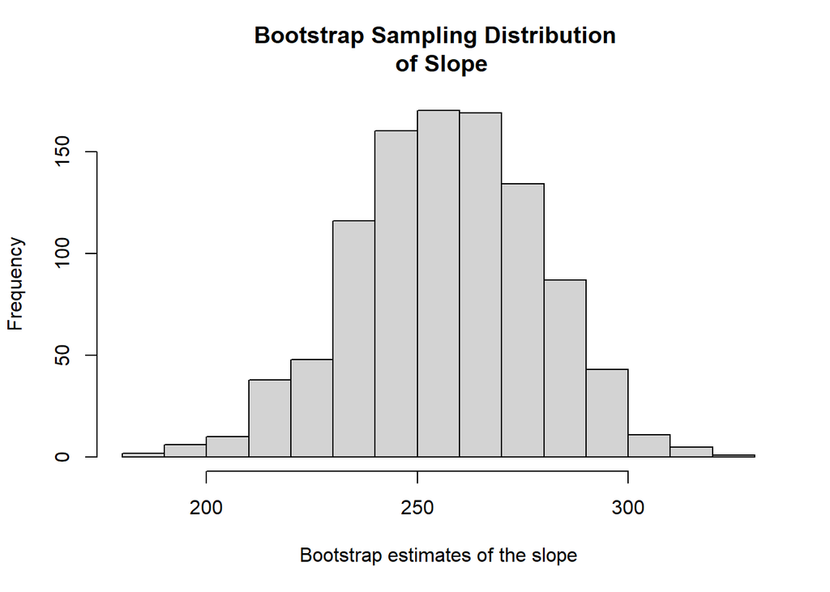

```r
hist(boot.beta1,                     # data used for histogram
     breaks = 14,                            # specify number of vertical bars
       xlab = "Bootstrap estimates of the slope",      # change the label of x-axis
      # add a title to the histogram
        main="Bootstrap Sampling Distribution \n of Slope")
```

Bootstrap sampling distribution plots can be seen above.

```r
##  95% bootstrap confidence intervals
boot.beta0.ci <- quantile(boot.beta0, c(0.025, 0.975), type = 2)
boot.beta1.ci <- quantile(boot.beta1, c(0.025, 0.975), type = 2)
boot.coef <- data.frame(rbind(boot.beta0.ci, boot.beta1.ci))
names(boot.coef) <- c("2.5%", "97.5%")
pander(boot.coef, caption="Bootstrap confidence intervals of regression coefficients.")
```

Bootstrap confidence intervals of regression coefficients.

|  | 2.5% | 97.5% |
| --- | --- | --- |
| **boot.beta0.ci** | 1491 | 4986 |
| **boot.beta1.ci** | 213.3 | 298.1 |